# Assignment1

Bayesian Data Analysis and Models of Behavior

Wenjie Tu

Spring Semester 2022

$~$

### 1 Six Dice Game

$~$

#### 1 (a) Theoretical expected payoff

$$P(X=k)=\binom{n}{k}p^{k}(1-p)^{n-k}$$

- $X$: the random variable that we want to model
- $n$: the total number of dice rolled in this game
- $k$: the number of dice landing with a face of 6
- $p$: the probability that a die lands with a face of 6

```r
## Initialize a 6x2 data frame
dat <- data.frame(matrix(nrow=7, ncol=3))
colnames(dat) <- c("Outcome", "Probability", "Payoff")

n <- nrow(dat)-1
for (k in 0:n) {
  dat[k+1, 1] <- k # the number dice showing 6 on the top
  dat[k+1, 2] <- choose(n, k) * (1/6)^k * (5/6)^(n-k) # probability
  dat[k+1, 3] <- ifelse(k==0, 0, 0.5*(1+k)) # payoff
}

## Print results in a table
knitr::kable(dat, align="c", caption="Six dice game")
```

Six dice game

| Outcome | Probability | Payoff |
| --- | --- | --- |
| 0 | 0.3348980 | 0.0 |
| 1 | 0.4018776 | 1.0 |
| 2 | 0.2009388 | 1.5 |
| 3 | 0.0535837 | 2.0 |
| 4 | 0.0080376 | 2.5 |
| 5 | 0.0006430 | 3.0 |
| 6 | 0.0000214 | 3.5 |

```r
## Expected payoff of playing this game
expected.payoff <- with(dat, Probability %*% Payoff)[1]; expected.payoff
```

```
## [1] 0.832551
```

We see that the expected payoff of playing this game is 0.833, which is smaller than the initial cost (i.e. 1) for playing such a game. Therefore, it is not a good idea to play this game.

$~$

#### 1 (b) Monte Carlo simulation

This game can be repeatedly played for thousands of times and the empirical expected payoff can be obtained. The simulation can simply be done in `R`. One can compare the empirical expected payoff with the initial cost of playing this game to see if this game is fair or not.

```r
## Set seed for reproducible results
set.seed(4321)

iterations <- 10000 # the number of iterations
cost <- 1           # the initial cost of playing the game one time

## Generate a data frame for plotting
d.payoff <- data.frame(matrix(nrow=iterations, ncol=3))
colnames(d.payoff) <- c("Iterations", "Payoff", "Expectation")

for (i in 1:iterations) {
  ## Roll 6 dice and store the outcome
  outcome <- sample(1:6, size=6, replace=TRUE)

  ## Compute the number of dice landing with 6 each time
  n.six <- sum(outcome==6)

  ## Store the iteration index in the first column
  d.payoff[i, 1] <- i

  ## Store the payoff for each iteration in the second column
  d.payoff[i, 2] <- ifelse(n.six==0, 0, 0.5*(1+n.six))

  ## Compute the expected payoff in the third column
  d.payoff[i, 3] <- mean(d.payoff[1:i, 2])
}
```

```r
## Load packages for generating plots
library(ggplot2)
library(gganimate)
library(gifski)
```

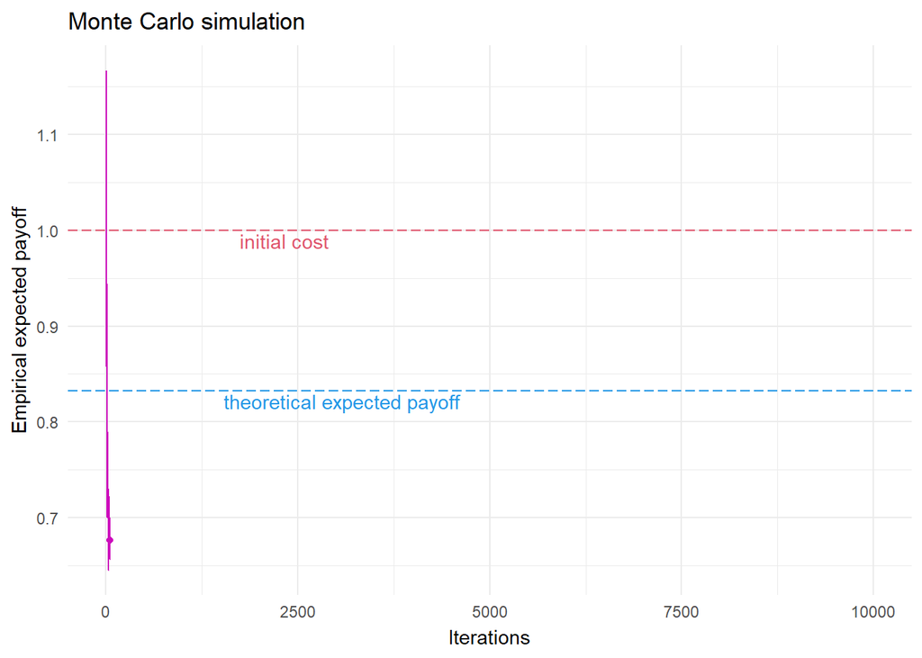

```r
ggplot(d.payoff, aes(x=Iterations, y=Expectation)) +
  geom_line(color=6) +
  geom_point(color=6) +
  geom_hline(yintercept=expected.payoff, color=4, linetype="longdash") +
  geom_text(aes(0, expected.payoff, label="theoretical expected payoff", vjust=1.2, hjust=-0.5), color=4) +
  geom_hline(yintercept=cost, color=2, linetype="longdash") +
  geom_text(aes(0, cost, label="initial cost", vjust=1.2, hjust=-1.5), color=2) +
  labs(title="Monte Carlo simulation", x="Iterations", y="Empirical expected payoff") +
  theme_minimal() +
  transition_reveal(Iterations)
```

$~$

### 2 Metropolis Algorithm

Metropolis algorithm works as follows:

- Initialize a starting point as the current position (denoted by $\theta_\text{cur}$)
- Propose a $\theta_\text{pro}$ generated from a normal distribution with a mean of previous $\theta$ and a standard deviation of 0.2

  $$\theta_\text{pro}\sim\mathcal{N}(\theta_\text{cur},
  0.2^2)$$
  - We are modeling the probability distribution of the number of heads in a sequence of $N=20$ independent coin-flipping game with two possible outcomes (i.e. binomial distribution)
  - The parameter of interest ($\theta$) must be bounded between 0 and 1
  - Therefore, we refine the proposed distribution:

    $$\theta_\text{pro}=
    \begin{cases}
    0, & \theta_\text{pro}<0 \\
    \theta_\text{pro}, & 0<\theta_\text{pro}<1 \\
    1, & \theta_\text{pro}>1 \\
    \end{cases}$$
- Compute the prior probabilities of $\theta_\text{cur}$ and $\theta_\text{pro}$
  - Since we have a flat prior over $\theta$ (i.e. $\text{Beta}(1,1)$ is the beta form of uniform distribution), we can simply drop out the priors when computing the posteriors
- Compute the likelihood functions of $\theta_\text{cur}$ and $\theta_\text{pro}$ (binomial distribution)
- Compute the posterior probabilities of $\theta_\text{cur}$ and $\theta_\text{pro}$ (posterior is proportional to the likelihood function times the prior)
- Compute the acceptance ratio $p_\text{move}$

  $$\begin{aligned}
  p_\text{move}
  &= \min\left(1,
  \frac{\text{posterior pribability of }\theta_\text{pro}}{\text{posterior
  pribability of }\theta_\text{cur}}
  \right) \\
  &= \min\left(1, \frac{\text{Binomial}(z,N\mid
  \theta_\text{pro})\cdot\text{Beta}(\theta_\text{pro}\mid
  a,b)}{\text{Binomial}(z,N\mid
  \theta_\text{cur})\cdot\text{Beta}(\theta_\text{cur}\mid a,b)} \right)
  \end{aligned}$$
  - If $p_\text{move}\geq 0$, then accept the sample for sure by setting $\theta_\text{cur}$ to $\theta_\text{pro}$
  - If $p_\text{move}< 0$, then accept the sample with a probability of $p_\text{move}$. We proceeds by generating a uniform random number $u\in[0, 1]$. We accept the sample if $p_\text{move}>u$, otherwise we reject the sample by staying in the current island (setting $\theta_\text{cur}$ to $\theta_\text{cur}$)

$~$

#### 2 (a) Implementation with R

```r
## Set seed for reproducible results
set.seed(2022)

## Function: chainGenerator()
## Arguments: start, n.samples, sigma, N, z, a, b
chainGenerator <- function(
    start,          # starting point
    n.samples=5000, # total number of samples generated
    sigma=0.2,      # standard deviation for the random draws
    N=20, z=14,     # parameters for the binomial distribution
    a=1, b=1        # parameters for the Beta distribution
  ) {
  chain <- numeric(n.samples) # initialize a vector to store samples
  chain[1] <- start           # set the first position of the vector to the starting point
  for (i in 1:(n.samples-1)) {
    theta.cur <- chain[i]
    theta.pro <- theta.cur + rnorm(1, mean=0, sd=sigma)
    theta.pro <- min(1, max(0, theta.pro))

    ## Posterior probability of the current theta
    posterior.cur <- dbinom(z, size=N, prob=theta.cur) * dbeta(theta.cur, a, b)

    ## Posterior probability of the proposed theta
    posterior.pro <- dbinom(z, size=N, prob=theta.pro) * dbeta(theta.pro, a, b)

    prob.move <- min(1, (posterior.pro/posterior.cur))

    ## Compare the probability of moving to a uniform draw from 0 to 1
    if (prob.move > runif(1, min=0, max=1)) {
      chain[i+1] <- theta.pro # accept the proposed sample
    } else {
      chain[i+1] <- theta.cur # reject the proposed sample
    }
  }
  return(chain)
}
```

```r
## Generate three chains starting at 0.1, 0.9, 0.5 respectively
chain1 <- chainGenerator(start = 0.1)
chain2 <- chainGenerator(start = 0.9)
chain3 <- chainGenerator(start = 0.5)
```

$~$

#### 2 (b) Overlaying three chains

```r
chains.r <- data.frame(
  ## Drop the first 2500 samples as burnins for each chain
  theta=c(chain1[2501:5000], chain2[2501:5000], chain3[2501:5000]),
  iteration=rep(2501:5000, times=3), index=1:7500,
  chainType=rep(c("chain1", "chain2", "chain3"), each=2500)
)
```

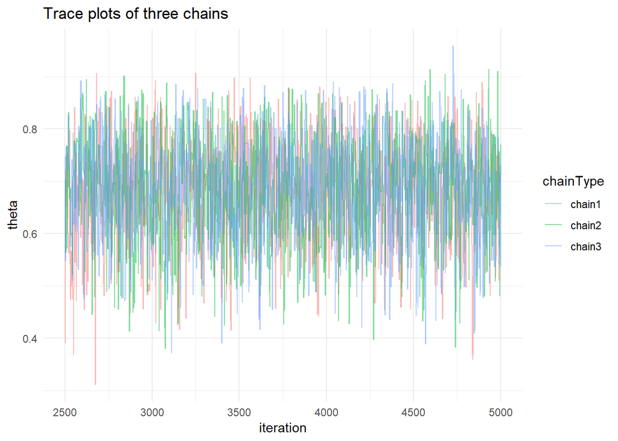

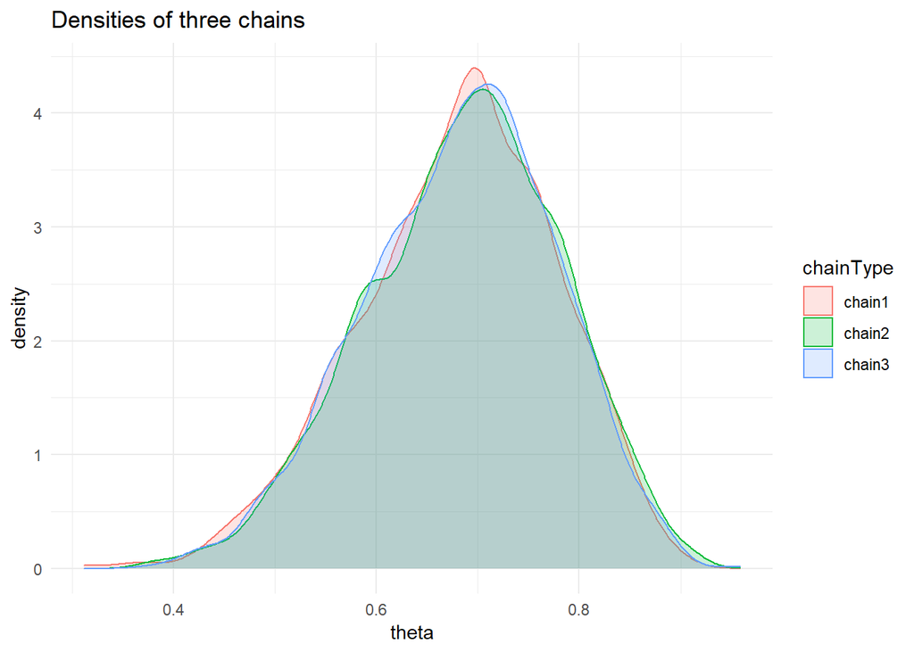

```r
ggplot(chains.r, aes(x=iteration, y=theta, col=chainType)) +
  geom_line(alpha=0.5) + # geom_point() +
  ggtitle("Trace plots of three chains") +
  theme_minimal()

ggplot(chains.r, aes(x=theta, col=chainType, fill=chainType)) +
  geom_density(alpha=0.2) +
  labs(title="Densities of three chains") +
  theme_minimal()
```

By overlaying trace plots and density plots of three chains, we can see that the three chains converge to the same posterior distribution. To see it more clear, we overlay densities of three chains and the densities overlap quite a bit.

$~$

#### 2 (c) Concatenating three chains

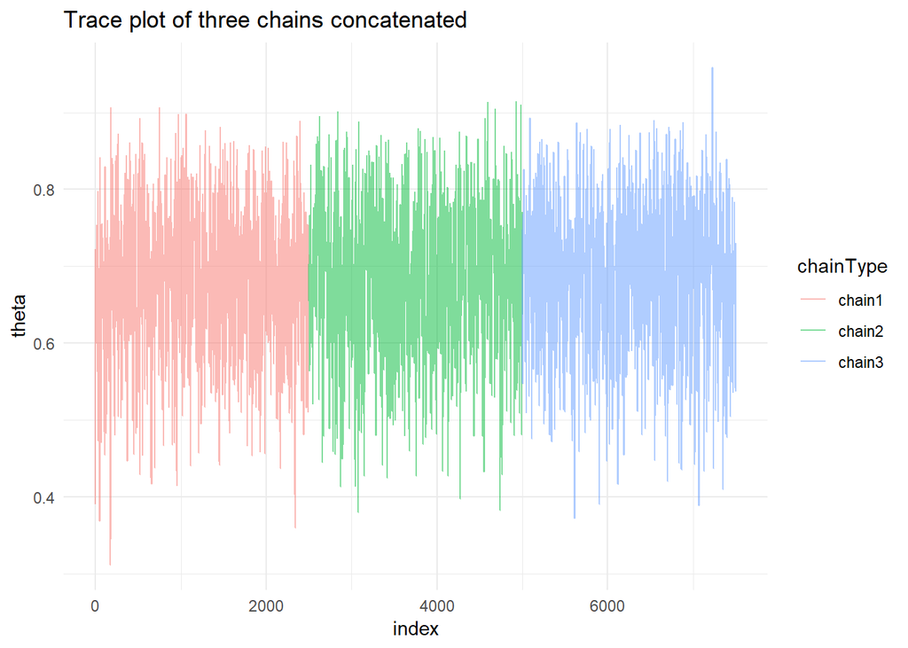

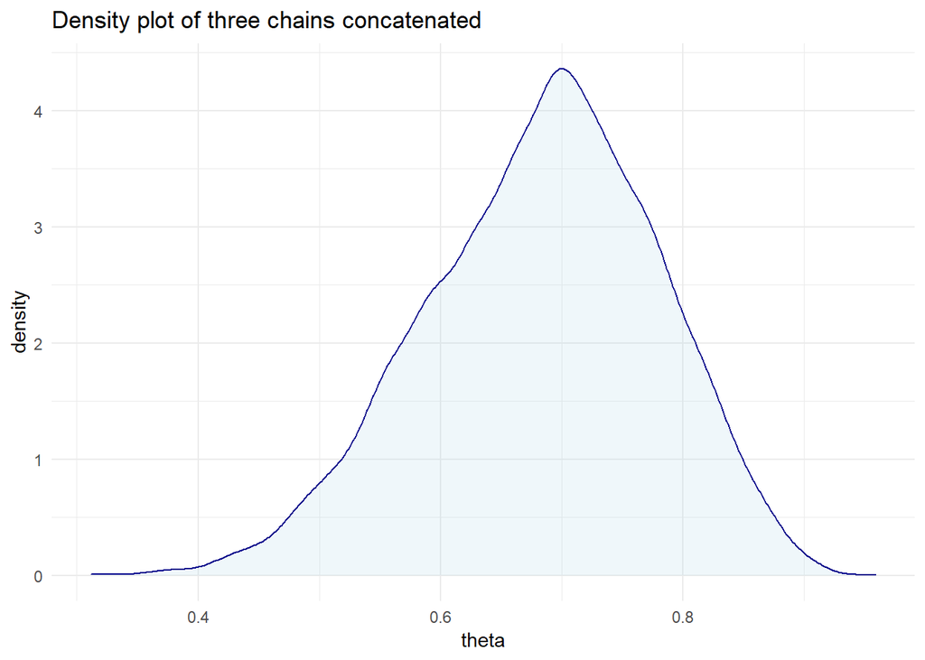

```r
ggplot(chains.r, aes(x=index, y=theta, col=chainType)) +
  geom_line(alpha=0.5) +
  ggtitle("Trace plot of three chains concatenated") +
  theme_minimal()

ggplot(chains.r, aes(x=theta)) +
  geom_density(alpha=0.2, color="darkblue", fill="lightblue") +
  labs(title="Density plot of three chains concatenated") +
  theme_minimal()
```

```r
source("./scripts/HDIofMCMC.r")

hdi.r <- HDIofMCMC(chains.r$theta, credMass=0.95); hdi.r
```

```
## [1] 0.4996682 0.8664425
```

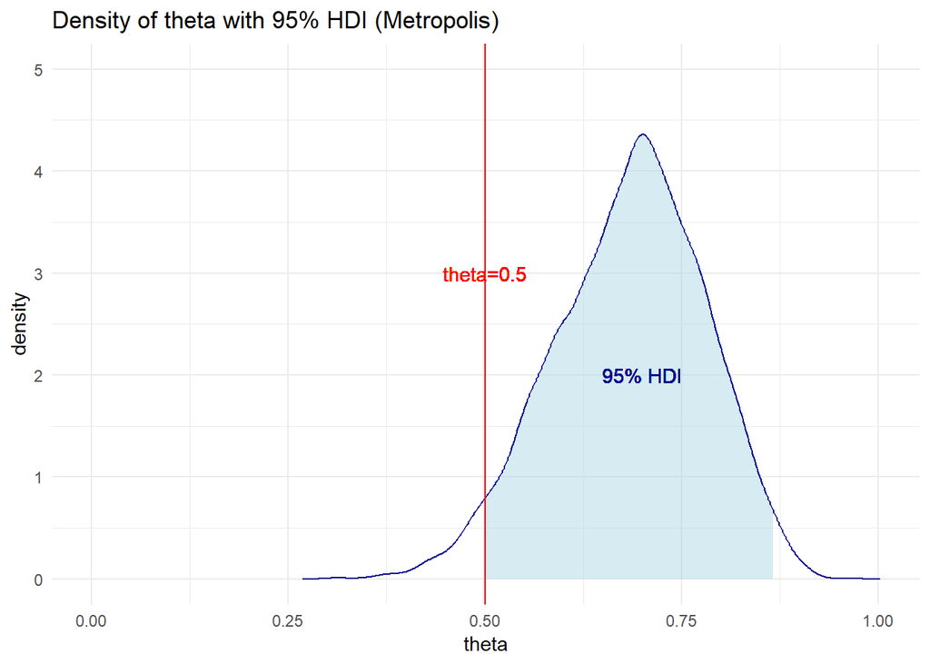

```r
d.plot <- with(density(chains.r$theta), data.frame(x, y))
ggplot(data=d.plot, mapping=aes(x=x, y=y)) +
  geom_area(aes(x=ifelse(x>hdi.r[1] & x<hdi.r[2], x, 0), y=y), fill="lightblue", alpha=0.5) +
  geom_line(color="darkblue") +
  geom_vline(xintercept=0.5, color="red") + ylim(0, 5) + theme_minimal() +
  geom_text(aes(0.5, 3, label="theta=0.5"), color="red") +
  geom_text(aes(0.7, 2, label="95% HDI"), color="darkblue") +
  labs(title="Density of theta with 95% HDI (Metropolis)", x="theta", y="density")
```

It is a bit difficult to visually tell from the density plot whether the red vertical line $\theta=0.5$ lies in the 95% HDI but numerically we see that 0.5 lies in the 95% HDI.

$~$

#### 2 (d) Implementation with JAGS

```r
library(rjags)
library(runjags)
```

```r
if (!file.exists("./models/metropolis_model.txt")) {
  cat("model{
      theta ~ dbeta(1, 1)    # (uniform) prior

      for (i in 1:Ntotal) {
        y[i] ~ dbern(theta)  # likelihood
      }
  }", file="./models/metropolis_model.txt")
} else {
  print("The text file for Metropolis model already existed!")
}
```

```
## [1] "The text file for Metropolis model already existed!"
```

```r
n.flips <- 20 # the number of flips
n.heads <- 14 # the number of heads
y <- rep(c(1, 0), times=c(n.heads, n.flips-n.heads))
Ntotal <- length(y)

n.burnin <- 2500
n.samples <- 2500
n.thin <- 1

## Prepare the data for JAGS
dat <- dump.format(list(y=y, Ntotal=Ntotal))

## Initialize the variables and chains
inits1 <- dump.format(list(theta=0.1, .RNG.name="base::Super-Duper", .RNG.seed=99999 ))
inits2 <- dump.format(list(theta=0.9, .RNG.name="base::Wichmann-Hill", .RNG.seed=1234 ))
inits3 <- dump.format(list(theta=0.5, .RNG.name="base::Mersenne-Twister", .RNG.seed=6666 ))

## Tell JAGS which latent variables to monitor
monitor = c("theta")

## Run JAGS
results <- run.jags(
  model="./models/metropolis_model.txt",
  monitor = monitor,
  data = dat,
  n.chains = 3,
  inits = c(inits1, inits2, inits3),
  burnin = n.burnin,
  sample = n.samples,
  thin = n.thin,
  adapt = 0
)
```

```
## Compiling rjags model...
## Calling the simulation using the rjags method...
## Burning in the model for 2500 iterations...
## Running the model for 2500 iterations...
## Simulation complete
## Calculating summary statistics...
## Calculating the Gelman-Rubin statistic for 1 variables....
## Finished running the simulation
```

```r
## Print the summary results of the Metropolis algorithm in a table
knitr::kable(summary(results), caption="Summary results of the Metropolis algorithm")
```

Summary results of the Metropolis algorithm

|  | Lower95 | Median | Upper95 | Mean | SD | Mode | MCerr | MC%ofSD | SSeff | AC.10 | psrf |
| --- | --- | --- | --- | --- | --- | --- | --- | --- | --- | --- | --- |
| theta | 0.493841 | 0.6864112 | 0.8597397 | 0.6814065 | 0.0959682 | NA | 0.0011363 | 1.2 | 7133 | 0.0194693 | 0.9999852 |

We see from the summary results that 0.5 lies in the 95% highest density interval $(0.493841, 0.8597397)$ and that **psrf** (convergence diagnostic) is very close to 1 (which indicates the current distribution converges to the target distribution).

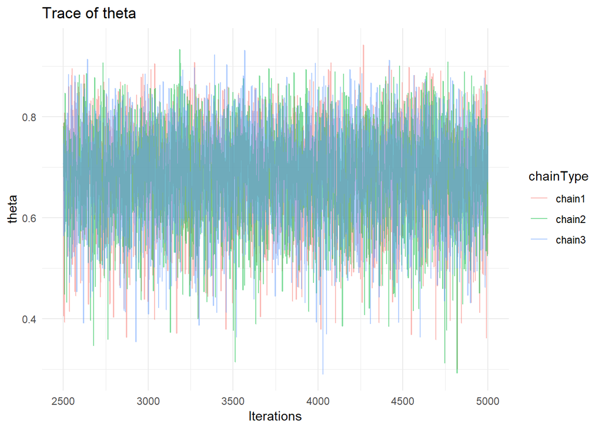

```r
chains.jags <- data.frame(
  chainType=rep(c("chain1", "chain2", "chain3"), each=2500),
  index=rep(seq(2501, length.out=2500), times=3),
  theta=rbind(results$mcmc[[1]], results$mcmc[[2]], results$mcmc[[3]])
)

ggplot(data=chains.jags) +
  geom_line(aes(x=index, y=theta, color=chainType), alpha=0.5) +
  labs(title="Trace of theta", x="Iterations") +
  theme_minimal()
```

```r
hdi.jags <- HDIofMCMC(chains.jags$theta, credMass=0.95); hdi.jags
```

```
## [1] 0.4938410 0.8597397
```

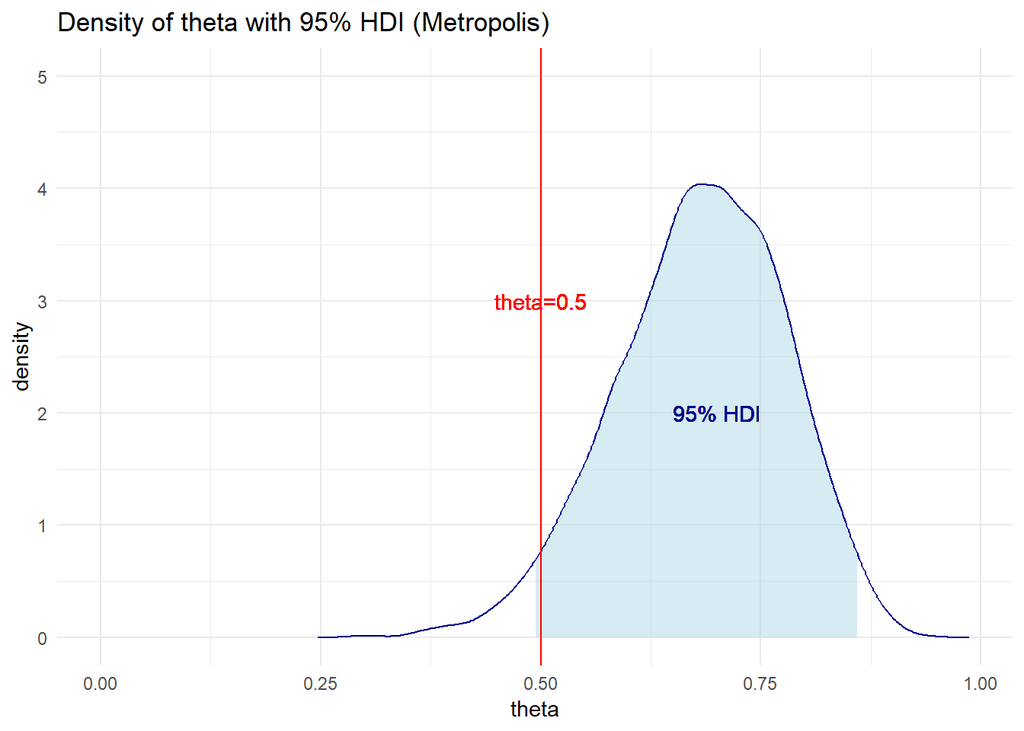

```r
d.plot <- with(density(chains.jags$theta), data.frame(x, y))
ggplot(data=d.plot, mapping=aes(x=x, y=y)) +
  geom_area(aes(x=ifelse(x>hdi.jags[1] & x<hdi.jags[2], x, 0), y=y), fill="lightblue", alpha=0.5) +
  geom_line(color="darkblue") +
  geom_vline(xintercept=0.5, color="red") +
  geom_text(aes(0.5, 3, label="theta=0.5"), color="red") +
  geom_text(aes(0.7, 2, label="95% HDI"), color="darkblue") +
  ylim(0, 5) +
  labs(title="Density of theta with 95% HDI (Metropolis)", x="theta", y="density") +
  theme_minimal()
```

We are able to visually detect that the red vertical line $\theta=0.5$ lies in the 95% HDI (blue shaded density).

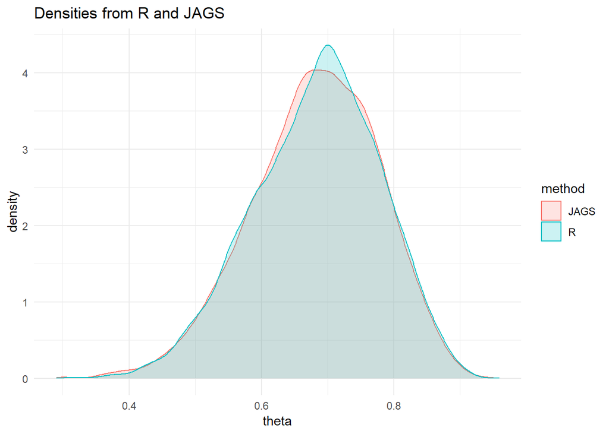

```r
d.plot <- data.frame(
  theta=c(chains.r$theta, chains.jags$theta),
  method=rep(c("R", "JAGS"), each=7500)
)

ggplot(d.plot, aes(x=theta, color=method, fill=method)) +
  geom_density(alpha=0.2) + theme_minimal() +
  labs(title="Densities from R and JAGS")
```

```r
cat(sprintf("HDI from R is (%.4f, %.4f)\nHDI from JAGS is (%.4f, %.4f)",
            hdi.r[1], hdi.r[2], hdi.jags[1], hdi.jags[2]))
```

```
## HDI from R is (0.4997, 0.8664)
## HDI from JAGS is (0.4938, 0.8597)
```

Metropolis algorithm implementation with both R and JAGS leads to the same conclusion - the coin is fair, since we see that 0.5 falls into the highest density intervals generated by both R function and JAGS

$~$

### 3 IQ Test

```r
# Load the required libraries
library(rjags)
library(runjags)
source("./scripts/HDIofMCMC.r") # Load the HDI function
```

```r
## Read in the data
df <- read.csv("./scripts/TwoGroupIQ.csv")

## Look at the data
rmarkdown::paged_table(df)
```

| Score | Group |
| --- | --- |
| 102 | Smart Drug |
| 107 | Smart Drug |
| 92 | Smart Drug |
| 101 | Smart Drug |
| 110 | Smart Drug |
| 68 | Smart Drug |
| 119 | Smart Drug |
| 106 | Smart Drug |
| 99 | Smart Drug |
| 103 | Smart Drug |

[output cut: 110 more lines]

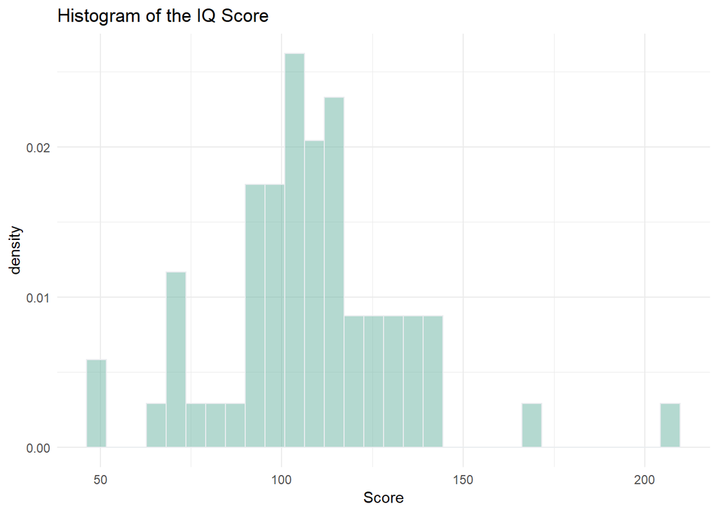

```r
## Plot histogram of IQ score in "Smart Drug" group
ggplot(subset(df, subset=Group=="Smart Drug", select="Score"), aes(x=Score, y=..density..)) +
  geom_histogram(bins=30, fill="#69b3a2", color="#e9ecef", alpha=0.5) +
  ggtitle("Histogram of the IQ Score") +
  theme_minimal()
```

$~$

#### 3 (a) Expected IQ score > 100 ?

```r
## Look at the model from the lecture 4
writeLines(readLines("models/oneSampleNorm.txt"))
```

```
## model {
##  mu ~ dnorm(0, 0.0001) # prior for the mean
##  sigma ~ dunif(0.0001, 100) # prior for the standard deviation
##
##  for (i in 1:Ntotal) {
##      y[i] ~ dnorm(mu, 1/sigma^2) # The normal distribution takes
##  }               # mean and precision --> precision = 1/sigma^2
##
## }
```

```r
## For purposes of this one-group example, use data from Smart Drug group:
IQscore <- df$Score[df$Group=="Smart Drug"]

## Save the length of the data and number of subjects (We want to pass this info to JAGS)
y <- IQscore
Ntotal <- length(y)

## Prepare the data for JAGS
dat <- dump.format(list(y=y, Ntotal=Ntotal))

## Initialize chains
inits1 <- dump.format(list(mu=100, sigma=30, .RNG.name="base::Super-Duper", .RNG.seed=99999 ))
inits2 <- dump.format(list(mu=120, sigma=20, .RNG.name="base::Wichmann-Hill", .RNG.seed=1234 ))
inits3 <- dump.format(list(mu=80, sigma=40, .RNG.name="base::Mersenne-Twister", .RNG.seed=6666 ))

## Tell JAGS which latent variables to monitor
monitor <- c("mu", "sigma")

## Run the function that fits the models using JAGS
results <- run.jags(
  model = "models/oneSampleNorm.txt",
  monitor = monitor,
  data = dat,
  n.chains = 3,
  inits = c(inits1, inits2, inits3),
  burnin = 4000, # the number of burnin iterations
  sample = 1000, # the total number of samples to take
  thin = 4       # the thinning interval
)
```

```
## Compiling rjags model...
## Calling the simulation using the rjags method...
## Adapting the model for 1000 iterations...
## Burning in the model for 4000 iterations...
## Running the model for 4000 iterations...
## Simulation complete
## Calculating summary statistics...
## Calculating the Gelman-Rubin statistic for 2 variables....
## Finished running the simulation
```

```r
## Print the summary of the results in a table
knitr::kable(summary(results), caption="Summary results for the IQ score")
```

Summary results for the IQ score

|  | Lower95 | Median | Upper95 | Mean | SD | Mode | MCerr | MC%ofSD | SSeff | AC.40 | psrf |
| --- | --- | --- | --- | --- | --- | --- | --- | --- | --- | --- | --- |
| mu | 101.41064 | 107.70673 | 114.26119 | 107.74443 | 3.283294 | NA | 0.0574772 | 1.8 | 3263 | 0.0232092 | 1.0004302 |
| sigma | 21.68927 | 25.85354 | 30.78132 | 26.02906 | 2.398510 | NA | 0.0437906 | 1.8 | 3000 | -0.0096451 | 0.9997772 |

```r
d.chains <- data.frame(
  chainType=rep(c("chain1", "chain2", "chain3"), each=1000),
  index=rep(seq(5001, by=4, length.out=1000), times=3),
  rbind(results$mcmc[[1]], results$mcmc[[2]], results$mcmc[[3]])
)

## Print the data frame
rmarkdown::paged_table(d.chains)
```

|  | chainType | index | mu | sigma |
| --- | --- | --- | --- | --- |
| X5001 | chain1 | 5001 | 111.09144 | 24.79590 |
| X5005 | chain1 | 5005 | 112.67965 | 23.12688 |
| X5009 | chain1 | 5009 | 111.18444 | 27.87374 |
| X5013 | chain1 | 5013 | 107.84374 | 22.38361 |
| X5017 | chain1 | 5017 | 113.02223 | 29.43414 |
| X5021 | chain1 | 5021 | 108.05565 | 26.36575 |
| X5025 | chain1 | 5025 | 106.86796 | 22.49462 |
| X5029 | chain1 | 5029 | 111.57358 | 24.97133 |
| X5033 | chain1 | 5033 | 108.10876 | 24.13856 |
| X5037 | chain1 | 5037 | 112.19662 | 25.95850 |

[output cut: 2990 more lines]

```r
## Trace plot of mu
trace.mu <- ggplot(data=d.chains) +
  geom_line(aes(x=index, y=mu, color=chainType), alpha=0.5) +
  labs(title="Trace of mu", x="Iterations") +
  theme_minimal()

## Density plot of mu
density.mu <- ggplot(d.chains) +
  geom_density(aes(x=mu), color="darkblue", fill="lightblue", alpha=0.5) +
  ggtitle("Density of mu") +
  theme_minimal()

## Trace plot of sigma
trace.sigma <- ggplot(data=d.chains) +
  geom_line(aes(x=index, y=sigma, color=chainType), alpha=0.5) +
  labs(title="Trace of sigma", x="Iterations") +
  theme_minimal()

## Density plot of sigma
density.sigma <- ggplot(d.chains) +
  geom_density(aes(x=sigma), color="darkblue", fill="lightblue", alpha=0.5) +
  ggtitle("Density of sigma") +
  theme_minimal()
```

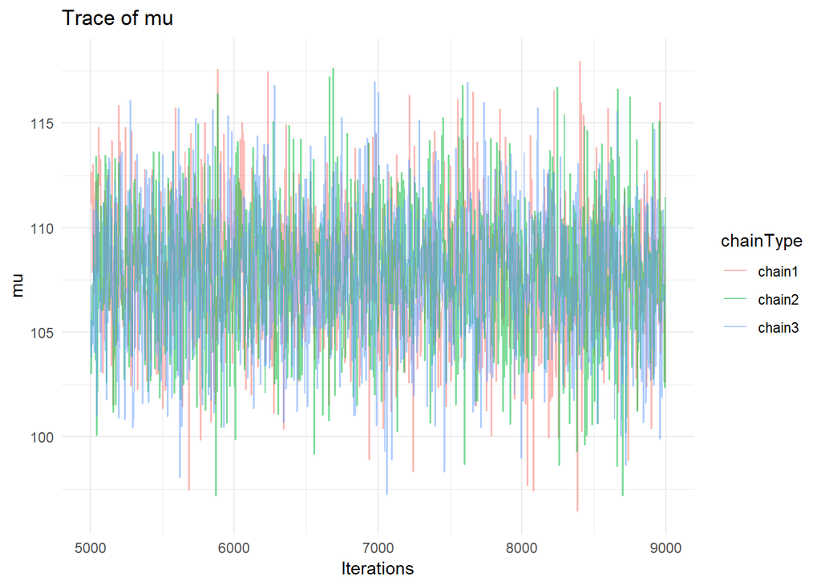

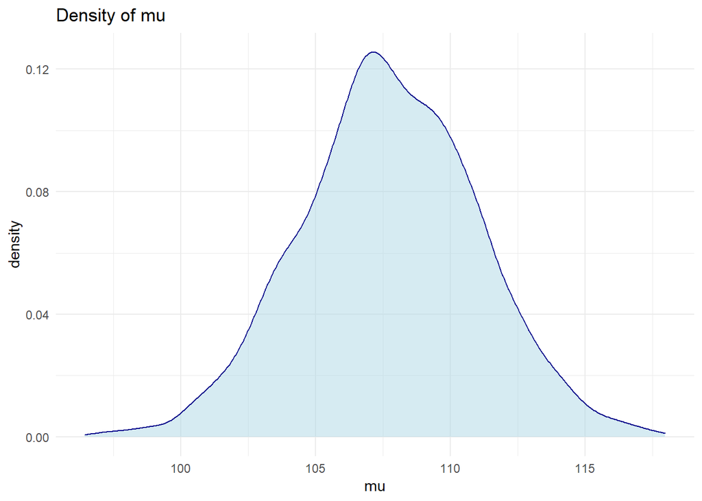

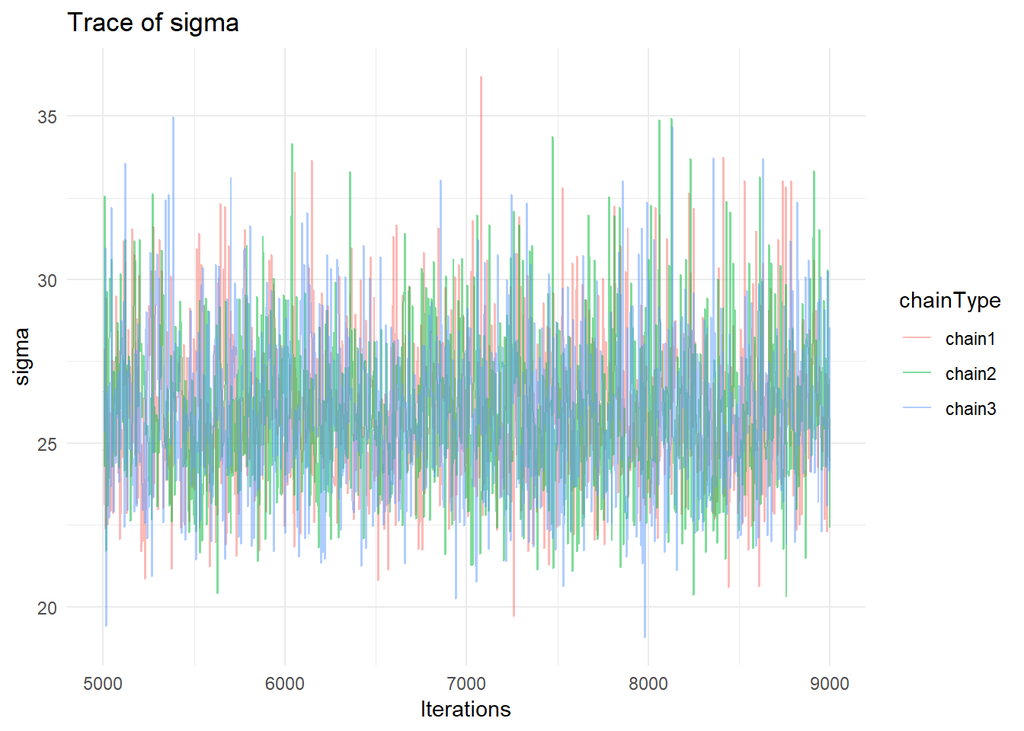

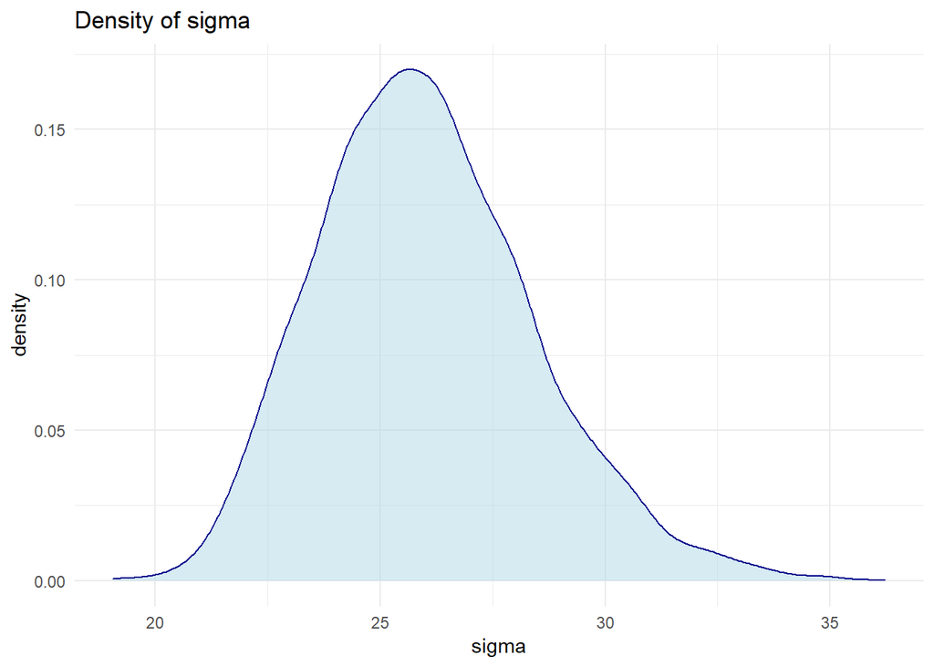

```r
trace.mu; density.mu; trace.sigma; density.sigma
```

```r
## Highest density interval (HDI)
hdi.mu <- HDIofMCMC(d.chains$mu, credMass=0.95); hdi.mu
```

```
## [1] 101.4106 114.2612
```

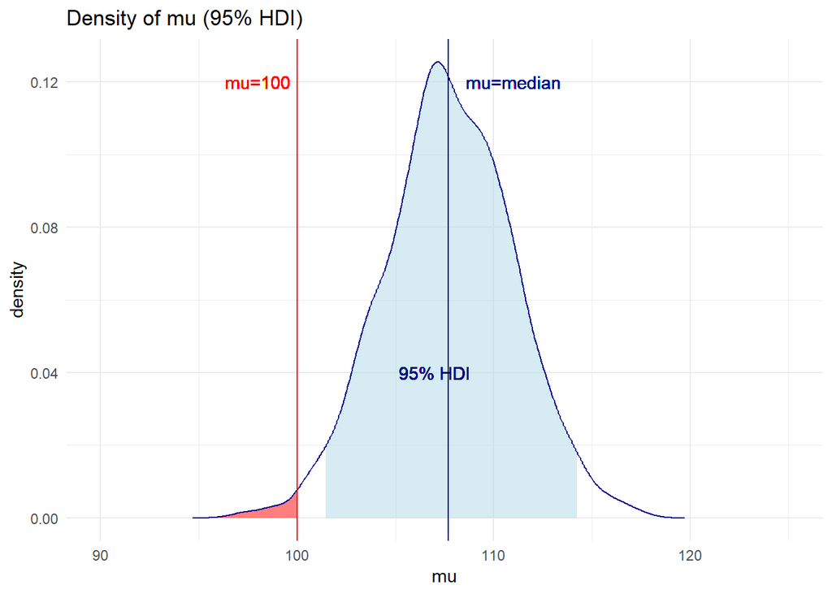

```r
d.plot <- with(density(d.chains$mu), data.frame(x, y))
ggplot(data=d.plot, mapping=aes(x=x, y=y)) +
  geom_area(aes(x=ifelse(x>hdi.mu[1] & x<hdi.mu[2], x, 0), y=y), fill="lightblue", alpha=0.5) +
  geom_area(aes(x=ifelse(x<100, x, 0), y=y), fill="red", alpha=0.5) +
  geom_line(color="darkblue") +
  xlim(90, 125) +
  geom_vline(xintercept=100, color="red") +
  geom_vline(xintercept=median(d.chains$mu), color="darkblue") +
  geom_text(aes(98, 0.12, label="mu=100"), color="red") +
  geom_text(aes(111, 0.12, label="mu=median"), color="darkblue") +
  geom_text(aes(107, 0.04, label="95% HDI"), color="darkblue") +
  labs(title="Density of mu (95% HDI)", x="mu", y="density") +
  theme_minimal()
```

- The light blue shaded area corresponds to the 95% highest density
- The red shaded area corresponds to the density probability of observing an IQ test with a value less than 100
- Visually it can be seen that these two shaded areas do not overlap. In other words, the 95% HDI does not cover 100. We thus conclude that the expected value of the IQ test is greater than 100

```r
## Compute the P[mu > 100]
prob <- mean(d.chains$mu>100); prob
```

```
## [1] 0.991
```

```r
## Compute the empirical cumulative distribution function
Fn <- ecdf(d.chains$mu)

## Calculate P[mu > 100] from empirical CDF
prob <- 1 - Fn(100); prob
```

```
## [1] 0.991
```

- `mean()` function is used to compute the posterior probability of $\mu>100$ since it returns the proportion of samples satisfying the condition
- Alternatively, `ecdf()` function can serve the same purpose as it estimates the empirical cumulative distribution function.
- $P(\mu>100)=0.991$. Therefore, we can conclude that the posterior probability of IQ score greater than 100 is 99.1%

$~$

#### 3 (b) Cohen’s d

**Standardized mean difference:**

A (population) effect size $d$ based on means usually considers the standardized mean difference between two populations:
$$d=\frac{\mu_1-\mu_2}{\sigma}$$
where $\mu_1$ is the mean for one population, $\mu_2$ is the mean for the other population, and $\sigma$ is the standard deviation based on either or both population.

Note: this form for the effect size resembles the computation for a $t$-test statistic with the critical difference that the $t$-test statistic includes a factor of $\sqrt{n}$. This means that for a given effect size, the significance level increases with the sample size. Unlike the $t$-test statistic, the effect size aims to estimate a population parameter and is not affected by the sample size.

```r
## Construct the effect size (Cohen's d)
cohen.d <- with(d.chains, (mu-100)/sigma)

## Compute the 95% HDI
hdi.cohend <- HDIofMCMC(cohen.d, credMass=0.95); hdi.cohend
```

```
## [1] 0.04306331 0.54692955
```

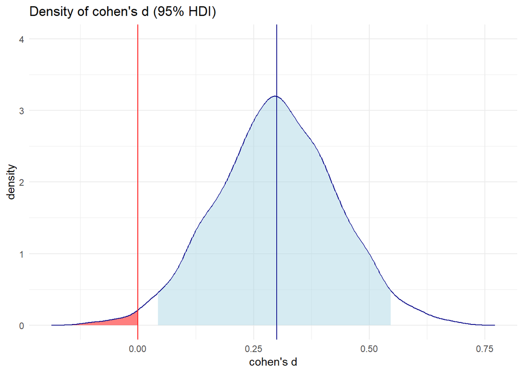

```r
d.plot <- with(density(cohen.d), data.frame(x, y))
ggplot(data=d.plot, mapping=aes(x=x, y=y)) +
  geom_area(aes(x=ifelse(x>hdi.cohend[1] & x<hdi.cohend[2], x, 0), y=y), fill="lightblue", alpha=0.5) +
  geom_area(aes(x=ifelse(x<=0, x, 0), y=y), fill="red", alpha=0.5) +
  geom_line(color="darkblue") +
  ylim(0, 4) +
  geom_vline(xintercept=median(cohen.d), color="darkblue") +
  geom_vline(xintercept=0, color="red") +
  labs(title="Density of cohen's d (95% HDI)", x="cohen's d", y="density") +
  theme_minimal()
```

The figure above displays the posterior distribution of the Cohen’s *d*. The 95% highest density is denoted by the blue shaded area and the posterior probability of $d\leq0$ is denoted by the red shaded area. We can visually tell that these two areas do not overlap, which indicates that the effect size is larger than 0. We can also compute the exact posterior probability of $d\leq0$ and get a numerical sense of how much evidence we have for the Cohen’s *d* larger than 0:

```r
## Compute P[d > 0]
prob <- mean(cohen.d > 0); prob
```

```
## [1] 0.991
```

```r
## Compute the empirical cumulative distribution function
Fn <- ecdf(cohen.d)

## Calculate P[d>0] from empirical CDF
prob <- 1 - Fn(0); prob
```

```
## [1] 0.991
```

Unsurprisingly, we obtain the same posterior probability for $d>0$ as we have for $\mu>100$ since these two in essence are the same. Therefore, we can conclude that the posterior probability of the effect size larger than 0 is 99.1% (i.e. $P(d>0)=99.1\%$).

```r
d.table <- data.frame(
  EffectSize=c("Very small", "Small", "Medium", "Large", "Very large", "Huge"),
  d=c(0.01, 0.20, 0.50, 0.80, 1.20, 2.0),
  Reference=c("Sawilowsky, 2009", "Cohen, 1988", "Cohen, 1988",
              "Cohen, 1988", "Sawilowsky, 2009", "Sawilowsky, 2009")
)
knitr::kable(d.table, caption="Effect Size Metric", align="c")
```

Effect Size Metric

| EffectSize | d | Reference |
| --- | --- | --- |
| Very small | 0.01 | Sawilowsky, 2009 |
| Small | 0.20 | Cohen, 1988 |
| Medium | 0.50 | Cohen, 1988 |
| Large | 0.80 | Cohen, 1988 |
| Very large | 1.20 | Sawilowsky, 2009 |
| Huge | 2.00 | Sawilowsky, 2009 |

```r
## Obtain the expected effect size
mean(cohen.d)
```

```
## [1] 0.3002752
```

The Cohen’s *d* is around 0.3. According to the effect size metric in the table above, we can conclude the effect size is between small and medium.

$~$

### 4 Model Comparison

```r
## Load the libraries
library(runjags)
library(rjags)

library(ggplot2)
library(GGally)
```

$~$

#### 4 (a) Visualization of raw data

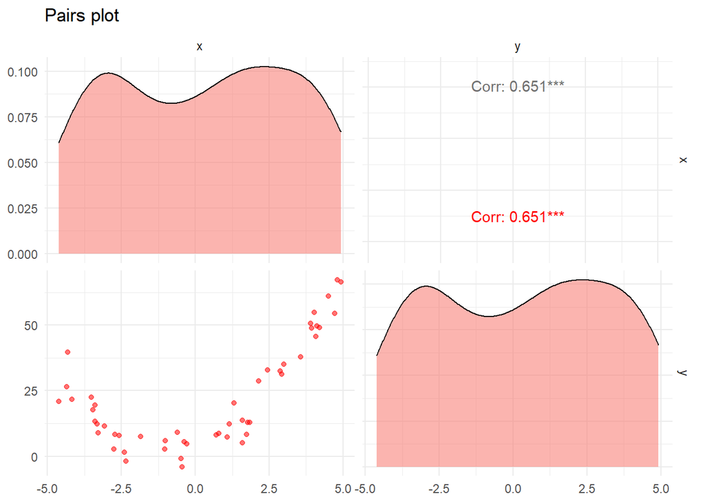

```r
## Load the data
load("dataFit.RData")

## Pairs plot
df <- data.frame(x = x, y = y)
ggpairs(df, aes(x=x, y=y, color="Corr", alpha=0.2)) +
  ggtitle("Pairs plot") + theme_minimal() +
  scale_colour_manual(values = "red")
```

$~$

#### 4 (b) Fitting different models

Null model:
$$y=a$$

Linear model:
$$y=a+bx$$

Quadratic model:
$$y=a+bx+cx^2$$

```r
## Null model
if (!file.exists("./models/null_model.txt")) {
  cat("model{
      a ~ dnorm(0, 0.00001)        # prior for the intercept
      sigma ~ dunif(0.00001, 100)  # prior for the sd of y

      for (i in 1:Ntotal) {
        y[i] ~ dnorm(a, 1/(sigma^2))
      }
  }", file="./models/null_model.txt")
} else {
  print("The null model text file already existed!")
}
```

```
## [1] "The null model text file already existed!"
```

```r
## Linear model
if (!file.exists("./models/linear_model.txt")) {
  cat("model{
      a ~ dnorm(0, 0.00001)        # prior for the intercept
      b ~ dnorm(0, 0.00001)        # prior for the slope
      sigma ~ dunif(0.00001, 100)  # prior for the sd of y

      for (i in 1:Ntotal) {
        mu[i] <- a + b * x[i]
        y[i] ~ dnorm(mu[i], 1/(sigma^2))
      }
  }", file="./models/linear_model.txt")
} else {
  print("The linear model text file already existed!")
}
```

```
## [1] "The linear model text file already existed!"
```

```r
## Quadratic model
if (!file.exists("./models/quadratic_model.txt")) {
  cat("model{
      a ~ dnorm(0, 0.00001)        # prior for the intercept
      b ~ dnorm(0, 0.00001)        # prior for the slope
      c ~ dnorm(0, 0.00001)        # prior for the quadratic term
      sigma ~ dunif(0.00001, 100)  # prior for the sd of y

      for (i in 1:Ntotal) {
        mu[i] <- a + b * x[i] + c * x[i]^2
        y[i] ~ dnorm(mu[i], 1/(sigma^2))
      }
  }", file="./models/quadratic_model.txt")
} else {
  print("The quadratic model text file already existed!")
}
```

```
## [1] "The quadratic model text file already existed!"
```

```r
## Prepare the data for JAGS
dat <- dump.format(list(y=y, x=x, Ntotal=length(x)))

## Initialize each chain
inits1 <- dump.format(list(.RNG.name="base::Super-Duper", .RNG.seed=99999 ))
inits2 <- dump.format(list(.RNG.name="base::Wichmann-Hill", .RNG.seed=1234 ))
inits3 <- dump.format(list(.RNG.name="base::Mersenne-Twister", .RNG.seed=6666 ))

## Tell JAGS which latent variables to monitor for each model
## We also need to monitor deviance to compute the dic
monitor0 <- c("a", "sigma", "deviance")
monitor1 <- c("a", "b", "sigma",  "deviance")
monitor2 <- c("a", "b", "c", "sigma", "deviance")

## Parameters for JAGS
n.samples <- 1000  # the number of samples to take
n.burnin  <- 5000  # the number of burnin iterations
n.thin    <- 5     # the thinning interval
```

```r
## Null model: y = a
if (!exists("results0")) {
  results0 <- run.jags(
    model = "models/null_model.txt",
    monitor = monitor0,
    data = dat,
    n.chains = 3,
    inits = c(inits1, inits2, inits3),
    burnin = n.burnin,
    sample = n.samples,
    thin = n.thin
  )
} else {
  print("Results for the null model already existed!")
}
```

```
## module dic loaded
```

```
## Compiling rjags model...
## Calling the simulation using the rjags method...
## Adapting the model for 1000 iterations...
## Burning in the model for 5000 iterations...
## Running the model for 5000 iterations...
## Simulation complete
## Calculating summary statistics...
## Calculating the Gelman-Rubin statistic for 3 variables....
## Finished running the simulation
```

```r
## Linear model: y = a + b*x
if (!exists("results1")) {
  results1 <- run.jags(
    model = "models/linear_model.txt",
    monitor = monitor1,
    data = dat,
    n.chains = 3,
    inits = c(inits1, inits2, inits3),
    burnin = n.burnin,
    sample = n.samples,
    thin = n.thin
  )
} else {
  print("Results for the linear model already existed")
}
```

```
## Compiling rjags model...
## Calling the simulation using the rjags method...
## Adapting the model for 1000 iterations...
## Burning in the model for 5000 iterations...
## Running the model for 5000 iterations...
## Simulation complete
## Calculating summary statistics...
## Calculating the Gelman-Rubin statistic for 4 variables....
## Finished running the simulation
```

```r
if (!exists("results2")) {
  results2 <- run.jags(
    model = "models/quadratic_model.txt",
    monitor = monitor2,
    data = dat,
    n.chains = 3,
    inits = c(inits1, inits2, inits3),
    burnin = n.burnin,
    sample = n.samples,
    thin = n.thin
  )
} else {
  print("Results for the quadratic model already existed")
}
```

```
## Compiling rjags model...
## Calling the simulation using the rjags method...
## Adapting the model for 1000 iterations...
## Burning in the model for 5000 iterations...
## Running the model for 5000 iterations...
## Simulation complete
## Calculating summary statistics...
## Calculating the Gelman-Rubin statistic for 5 variables....
## Finished running the simulation
```

```r
## Summary results for null model
knitr::kable(summary(results0), caption="Summary results for the null model", digits=4)
```

Summary results for the null model

|  | Lower95 | Median | Upper95 | Mean | SD | Mode | MCerr | MC%ofSD | SSeff | AC.50 | psrf |
| --- | --- | --- | --- | --- | --- | --- | --- | --- | --- | --- | --- |
| a | 17.2359 | 22.4181 | 28.3472 | 22.3764 | 2.8006 | NA | 0.0511 | 1.8 | 3000 | -0.0004 | 0.9999 |
| sigma | 16.3567 | 19.8854 | 24.3996 | 20.0208 | 2.0850 | NA | 0.0381 | 1.8 | 3000 | -0.0058 | 0.9997 |
| deviance | 438.2664 | 439.7050 | 444.2393 | 440.3188 | 2.0099 | NA | 0.0386 | 1.9 | 2714 | -0.0003 | 1.0003 |

```r
## Summary results for linear model
knitr::kable(summary(results1), caption="Summary results for the linear model", digits=4)
```

Summary results for the linear model

|  | Lower95 | Median | Upper95 | Mean | SD | Mode | MCerr | MC%ofSD | SSeff | AC.50 | psrf |
| --- | --- | --- | --- | --- | --- | --- | --- | --- | --- | --- | --- |
| a | 17.0485 | 21.1993 | 25.8015 | 21.2020 | 2.1929 | NA | 0.0400 | 1.8 | 3000 | -0.0042 | 1.0004 |
| b | 2.8915 | 4.2394 | 5.6991 | 4.2344 | 0.7225 | NA | 0.0132 | 1.8 | 3000 | -0.0245 | 0.9996 |
| sigma | 12.3135 | 15.3196 | 18.6515 | 15.4363 | 1.6881 | NA | 0.0341 | 2.0 | 2452 | 0.0031 | 1.0005 |
| deviance | 410.7337 | 413.2767 | 419.1069 | 413.9140 | 2.5749 | NA | 0.0470 | 1.8 | 3000 | -0.0120 | 1.0002 |

```r
## Summary results for quadratic model
knitr::kable(summary(results2), caption="Summary results for the quadratic model", digits=4)
```

Summary results for the quadratic model

|  | Lower95 | Median | Upper95 | Mean | SD | Mode | MCerr | MC%ofSD | SSeff | AC.50 | psrf |
| --- | --- | --- | --- | --- | --- | --- | --- | --- | --- | --- | --- |
| a | 1.7208 | 3.9949 | 6.6291 | 3.9976 | 1.2374 | NA | 0.0247 | 2.0 | 2518 | -0.0011 | 1.0011 |
| b | 2.9377 | 3.4258 | 3.9545 | 3.4281 | 0.2577 | NA | 0.0047 | 1.8 | 2950 | 0.0222 | 1.0000 |
| c | 1.7151 | 1.9295 | 2.1277 | 1.9309 | 0.1048 | NA | 0.0020 | 1.9 | 2708 | -0.0124 | 1.0000 |
| sigma | 4.3243 | 5.2721 | 6.4978 | 5.3204 | 0.5688 | NA | 0.0105 | 1.8 | 2959 | 0.0053 | 1.0006 |
| deviance | 303.2327 | 306.6569 | 313.1700 | 307.4031 | 3.0414 | NA | 0.0615 | 2.0 | 2448 | 0.0061 | 1.0025 |

$~$

#### 4 (c) Visualization of data and models

```r
## Extract parameters from the summary results

## Null model: y = a0
a0 <- summary(results0)["a", "Mean"]

## Linear model: y = a1 + b1 * x
a1 <- summary(results1)["a", "Mean"]
b1 <- summary(results1)["b", "Mean"]

## Quadratic model: y = a2 + b2 * x + c2 * x^2
a2 <- summary(results2)["a", "Mean"]
b2 <- summary(results2)["b", "Mean"]
c2 <- summary(results2)["c", "Mean"]
```

```r
## Define the length of a grid of x-values
len <- 200

## Create a grid of x-values for prediction
x.grid <- seq(min(x), max(x), length.out=len)

## Predict y-values in the null model
y0.pred <- a0 + 0 * x.grid

## Predict y-values in the linear model
y1.pred <- a1 + b1 * x.grid

## Predict y-values in the quadratic model
y2.pred <- a2 + b2 * x.grid + c2 * x.grid^2
```

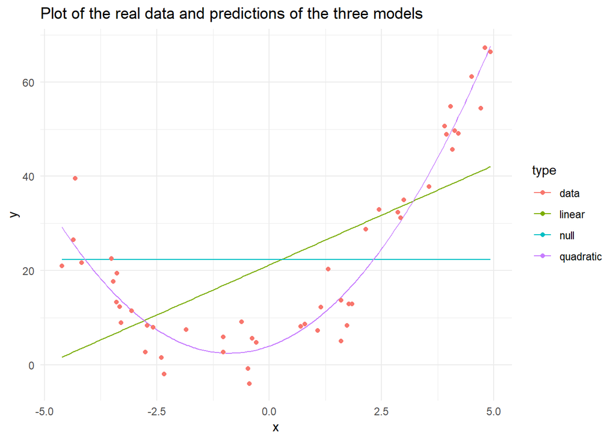

```r
d.plot <- data.frame(x=c(x.grid, x.grid, x.grid, x),
                     y=c(y0.pred, y1.pred, y2.pred, y),
                     type=rep(c("null", "linear", "quadratic", "data"),
                              times=c(rep(len, 3), length(x))))

ggplot() +
  geom_line(data=d.plot[d.plot$type!="data", ], aes(x=x, y=y, color=type)) +
  geom_point(data=d.plot[d.plot$type=="data", ], aes(x=x, y=y, color=type)) +
  ggtitle("Plot of the real data and predictions of the three models") +
  theme_minimal()
```

The figure displays three fits overlaid in the scatter plot of raw data. It is clear that the quadratic model fits the data the best against the other two.

$~$

#### 4 (d) Deviance information certerion

$$\texttt{DIC = mean(deviance) + (SD(deviance)^2)/2}$$

```r
## Null model
m.dev0 <- summary(results0)["deviance", "Mean"] # mean of deviance in null model
sd.dev0 <- summary(results0)["deviance", "SD"]  # sd of deviance in null model
bic0 <- m.dev0 + (sd.dev0^2)/2                  # dic estimate in null model

## Linear model
m.dev1 <- summary(results1)["deviance", "Mean"] # mean of deviance in linear model
sd.dev1 <- summary(results1)["deviance", "SD"]  # sd of deviance in linear model
bic1 <- m.dev1 + (sd.dev1^2)/2                  # dic estimate in linear model

## Quadratic model
m.dev2 <- summary(results2)["deviance", "Mean"] # mean of deviance in quadratic model
sd.dev2 <- summary(results2)["deviance", "SD"]  # sd of deviance in quadratic model
bic2 <- m.dev2 + (sd.dev2^2)/2                  # dic estimate in quadratic model
```

```r
d.dic <- data.frame(cbind(bic0, bic1, bic2))
colnames(d.dic) <- c("Null Model", "Linear Model", "Quadratic Model")
rownames(d.dic) <- "DIC"
knitr::kable(d.dic, align="c", caption="DICs for three models")
```

DICs for three models

|  | Null Model | Linear Model | Quadratic Model |
| --- | --- | --- | --- |
| DIC | 442.3387 | 417.2289 | 312.0282 |

The lower DIC indicates a better fit to the data. The table shows that the quadratic model yields the smallest DIC, thus the best fit out of three models, which is also consistent with what we see from the plot.